# Do some countries lag behind in equal rights trends?

L.-Y. M.

2024-03-17

# Introduction

Recently, Schaerer et al. (2023) reported that the gender discrimination of hiring decisions has been eliminated and even reversed. They performed a meta-analysis of 44 years, and recruited a “red team” (Lakens, 2020) to critique their work. I plaud for their rigorous work and the pursuit of best practices in science. However, as they mentioned, the heterogeneity of the true effects was extremely large (I<sup>2</sup>-statistic = 82.8%), implying that 82.8% of the total variance can be attributed to heterogeneity. The odd rate of discrimination, which is the ratio of the hiring rate of males to that of females, was 0.91 (95% confidence interval ranged from 0.86 to 0.97, z = -3.00, p =.003). But the 95% prediction interval is as wide as 0.49 to 1.70, which means that the true effect in a new study is expected to fall within this range with 95% probability. That is obvious from their Figure 4, which is pasted below.

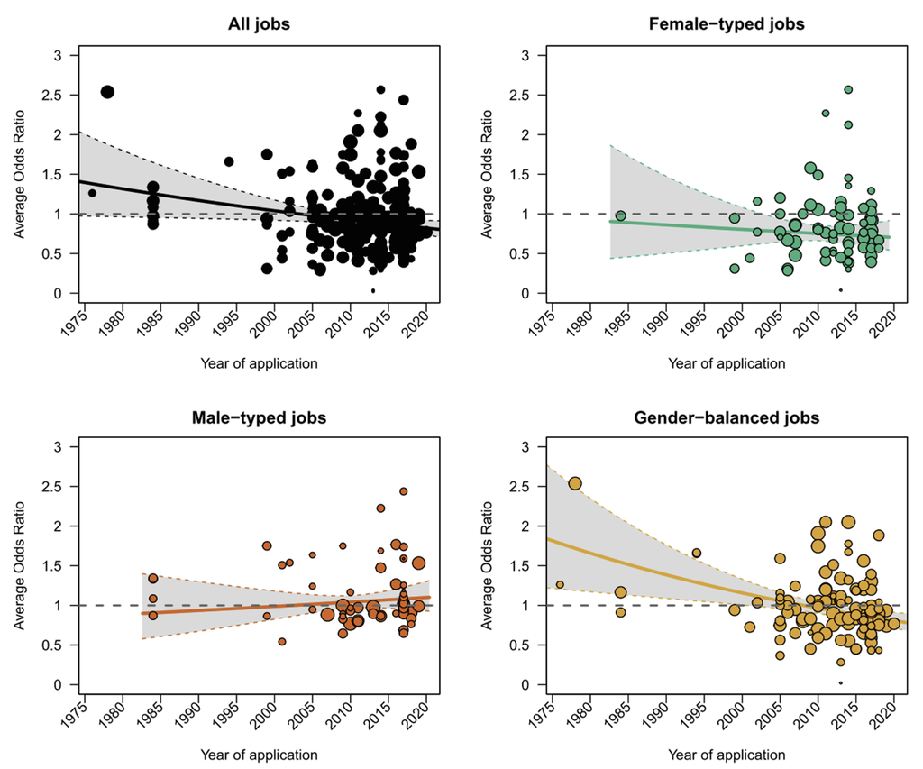

According to their data, the samples are biased towards the United States and Western Europe. They performed leave-one-out analysis, and examined the potential country-level confounders, like country’s gender inequality, country’s education level, GDP per capita, Human Development Index, and even culture (WEIRD index; Muthukrishna et al., 2020). However, I still wonder if their are some country-level confounders that they did not consider. Therefore, I would like to point out each country’s data to see if there are some country-level systematic biases.

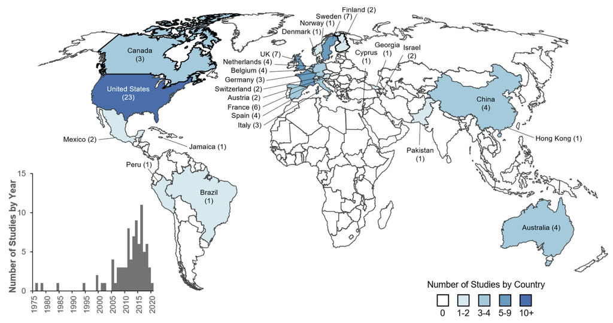

Thanks for their open science practice, I can access their data and code from [here](https://osf.io/pt4gn).

```r
## Load packages
library(tidyverse)
```

```r
library(cowplot)
## Load data
dat <- readxl::read_excel("Data.xlsx", sheet = "DATA")
```

# Plots

We will first calculate the mean odd rate of different countries or regions. Then we will highlight the countries or regions with the highest and lowest odd rates.

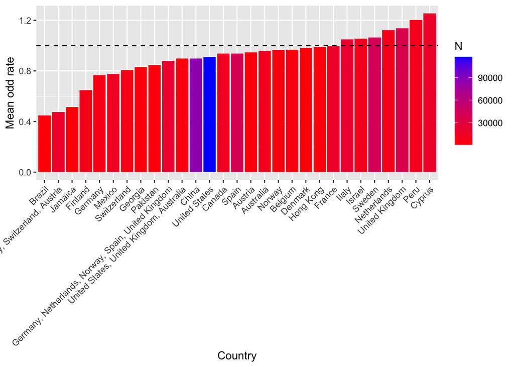

```r
# Odd rate
dat <- dat %>%
  mutate(OR = MaleSucc * FemaleFail / (MaleFail * FemaleSucc),
         N  = MaleN + FemaleN)
# Mean odd rate by country
dat_country <- dat %>%
  group_by(DataCounty) %>%
  summarise(mean_OR = mean(OR, na.rm = TRUE),
            N = sum(N, na.rm = TRUE)) %>%
  arrange(mean_OR)
# fig_country_mean
fig_country_mean <- dat_country %>%
  ggplot(aes(x = reorder(DataCounty, mean_OR), y = mean_OR, fill = N)) +
  geom_bar(stat = "identity") +
  scale_fill_gradient(low = "red", high = "blue") +
  labs(x = "Country", y = "Mean odd rate") +
  geom_hline(yintercept = 1, linetype = "dashed", color = "black") +
  theme(axis.text.x = element_text(angle = 45, hjust = 1))
fig_country_mean
```

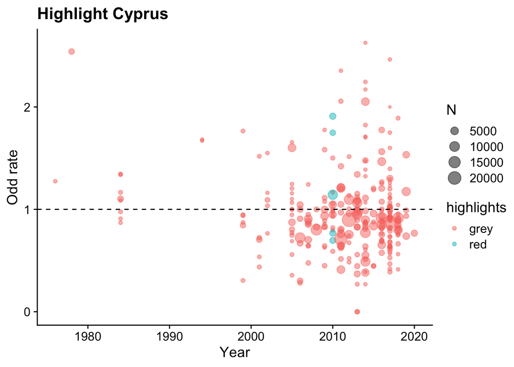

```r
colorset <- dat_country %>%
  select(DataCounty)
# highlight cyprus
colorset$highlights <- "grey"
colorset$highlights[colorset$DataCounty == "Cyprus"] <- "red"
dat_cyprus <- left_join(dat, colorset, by = "DataCounty")
# visualize cyprus
fig_cyprus <- dat_cyprus %>%
  ggplot(aes(x = ApplicYearMost, y = OR, color = highlights, size = N)) +
  geom_point(alpha = 0.5) +
  geom_hline(yintercept = 1, linetype = "dashed", color = "black") +
  theme_cowplot() +
  labs(title = "Highlight Cyprus", x = "Year", y = "Odd rate")
fig_cyprus
```

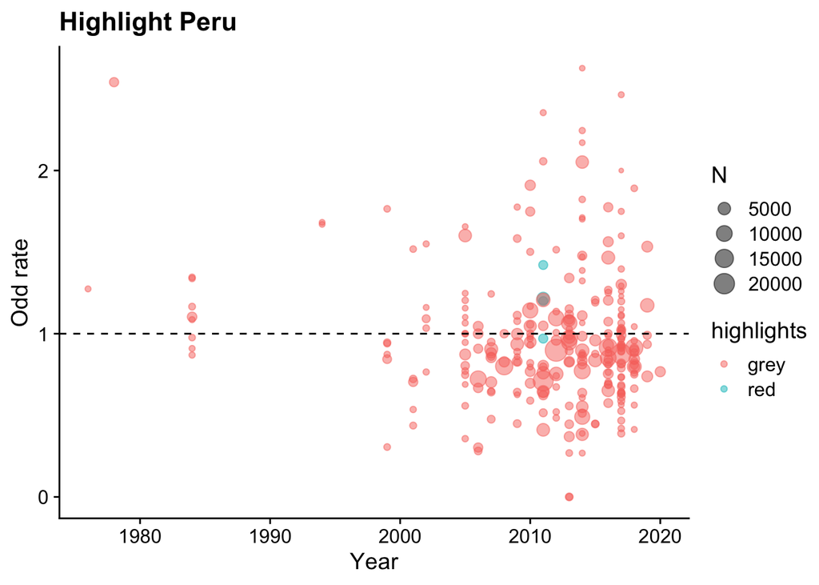

```r
# highlight peru
colorset$highlights <- "grey"
colorset$highlights[colorset$DataCounty == "Peru"] <- "red"
dat_peru <- left_join(dat, colorset, by = "DataCounty")
# visualize peru
fig_peru <- dat_peru %>%
  ggplot(aes(x = ApplicYearMost, y = OR, color = highlights, size = N)) +
  geom_point(alpha = 0.5) +
  geom_hline(yintercept = 1, linetype = "dashed", color = "black") +
  theme_cowplot() +
  labs(title = "Highlight Peru", x = "Year", y = "Odd rate")
fig_peru
```

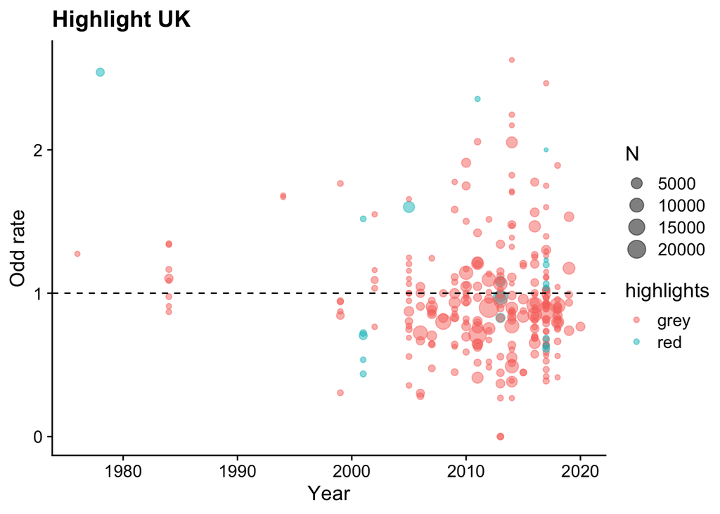

```r
# highlight UK
colorset$highlights <- "grey"
colorset$highlights[colorset$DataCounty == "United Kingdom"] <- "red"
dat_uk <- left_join(dat, colorset, by = "DataCounty")
# visualize UK
fig_uk <- dat_uk %>%
  ggplot(aes(x = ApplicYearMost, y = OR, color = highlights, size = N)) +
  geom_point(alpha = 0.5) +
  geom_hline(yintercept = 1, linetype = "dashed", color = "black") +
  theme_cowplot() +
  labs(title = "Highlight UK", x = "Year", y = "Odd rate")
fig_uk
```

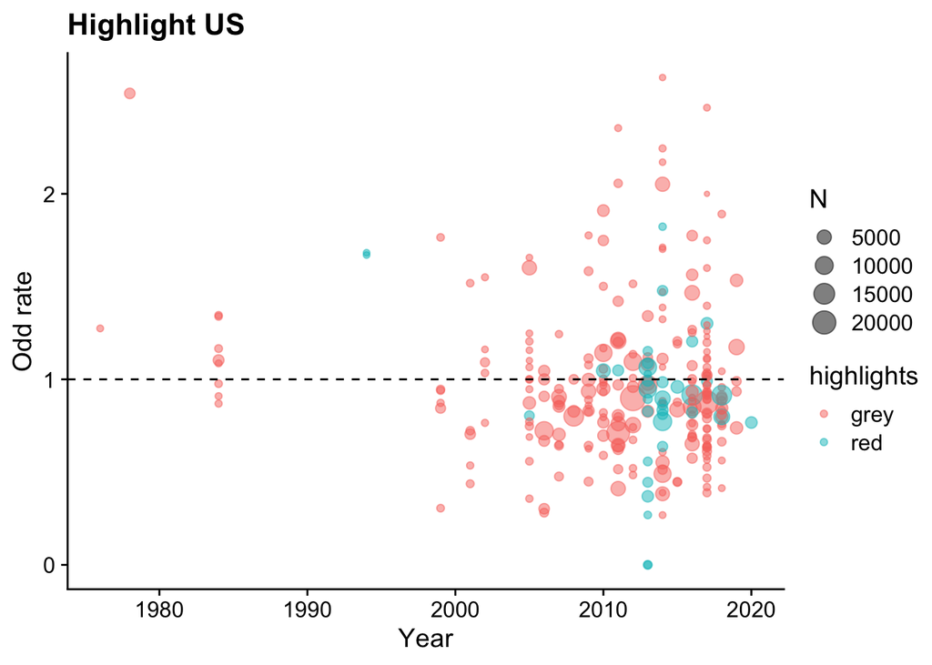

```r
# highlight US
colorset$highlights <- "grey"
colorset$highlights[colorset$DataCounty == "United States"] <- "red"
dat_us <- left_join(dat, colorset, by = "DataCounty")
# visualize US
fig_us <- dat_us %>%
  ggplot(aes(x = ApplicYearMost, y = OR, color = highlights, size = N)) +
  geom_point(alpha = 0.5) +
  geom_hline(yintercept = 1, linetype = "dashed", color = "black") +
  theme_cowplot() +
  labs(title = "Highlight US", x = "Year", y = "Odd rate")
fig_us
```

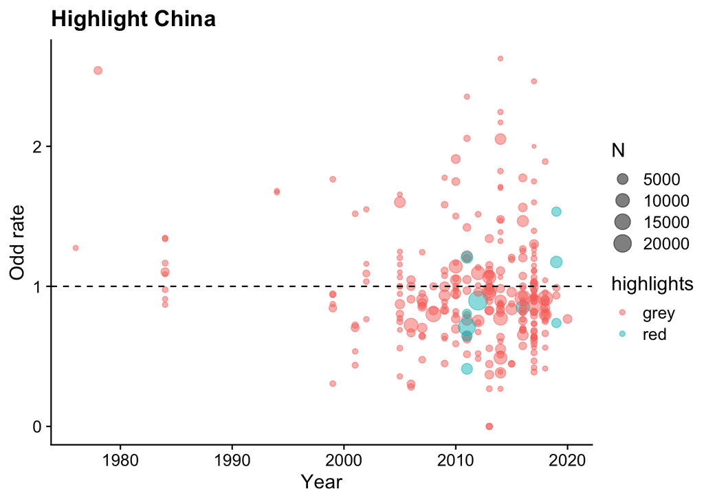

```r
# highlight CN
colorset$highlights <- "grey"
colorset$highlights[colorset$DataCounty == "China"] <- "red"
dat_cn <- left_join(dat, colorset, by = "DataCounty")
# visualize CN
fig_cn <- dat_cn %>%
  ggplot(aes(x = ApplicYearMost, y = OR, color = highlights, size = N)) +
  geom_point(alpha = 0.5) +
  geom_hline(yintercept = 1, linetype = "dashed", color = "black") +
  theme_cowplot() +
  labs(title = "Highlight China", x = "Year", y = "Odd rate")
fig_cn
```

to be continued…

# References

Lakens, D. (2020). Pandemic researchers–recruit your own best critics. Nature, 581(7807), 121–122. https://doi.org/10.1038/d41586-020-01392-8

Muthukrishna, M., Bell, A. V., Henrich, J., Curtin, C. M., Gedranovich, A., McInerney, J., & Thue, B. (2020). Beyond western, educated, industrial, rich, and democratic (WEIRD) psychology: Measuring and mapping scales of cultural and psychological distance. Psychological Science, 31(6), 678–701. https://doi.org/10.1177/0956797620916782

Schaerer, M., du Plessis, C., Nguyen, M. H. B., van Aert, R. C. M., Tiokhin, L., Lakens, D., Giulia Clemente, E., Pfeiffer, T., Dreber, A., Johannesson, M., Clark, C. J., & Luis Uhlmann, E. (2023). On the trajectory of discrimination: A meta-analysis and forecasting survey capturing 44 years of field experiments on gender and hiring decisions. Organizational Behavior and Human Decision Processes, 179. https://doi.org/10.1016/j.obhdp.2023.104280